# Tay-I: Taylor Swift Pop Verse Generator

## Spring 2024 Data Science Project

Group Members: Dhruv Rao (UID: 119010440), Vishnu Subramaniyan (UID: 118676548), Lance Uymatiao (UID: 118632605)

## Contribution Checkpoints:

A: Project idea - 5%

B: Dataset Curation and Preprocessing - 10%

C: Data Exploration and Summary Statistics - 10%

D: ML Algorithm Design/Development - 25%

E: ML Algorithm Training and Test Data Analysis - 20%

F: Visualization, Result Analysis, Conclusion - 15%

G: Final Tutorial Report Creation - 10%

H: Additional Resources - 5%

Member 1: Dhruv Rao, Contribution: 100%

Member 2: Vishnu Subramaniyan, Contribution: 100%

Member 3: Lance Uymatiao, Contribution: 100%

"We, all team members, agree together that the above information is true, and we are confident about our contributions to this submitted project/final tutorial."

Dhruv Rao - 5/7/24

Vishnu Subramaniyan - 5/7/24

Lance Uymatiao - 5/7/24

## Work Summary

Member 1: Dhruv Rao

My contributions were spread across the entire project. I worked on editing the Project Idea paragraph, wrote some of the explanations for our datasets and preprocessing, wrote Method 2 for data exploration, helped build out the Markov and RNN models and verse generators, and worked on BLEU accuracy and the bar graph of word frequencies. I also wrote parts of the conclusion and then aided in creation of the report.

Member 2: Vishnu Subramaniyan

I contributed eqaully throughout the entire project. I revised the project idea description, preprocessed our dataframes, wrote method 1 for dataset curation, edited both models/verse generators, and created several visualizations with their explanations. At the end, I set up the final report and reviewed the project alongside our team.

Member 3: Lance Uymatiao

I contributed towards all parts of the project. I brainstormed the original idea, preprocessed the dataframes, wrote method 3 for data exploration, made edits on both models, and performed sentiment analysis on Taylor's original lyrics and the results, graphing the outcomes. I also wrote part of the conclusion.

Taylor Swift has become a prominent artist across the pop music industry. She is well known for her heartfelt lyricism that resonates with her audience. Her ability to create touching, emotional songs has propelled her to the top of the music industry. In our attempt to explore and recreate her songwriting expertise, we present Tay-I: Taylor Swift Pop Verse Generator. By creating Taylor Swift's verse generator, we hope to reveal the top features of her songwriting process and recognize the underlying patterns and themes that define her style. We also seek to explore recurring themes across her songs, employ natural language processing and machine learning techniques to imitate her style, and analyze the generated verses' similarity to her actual lyrics through sentiment and word frequencies. Understanding the structure and patterns of Taylor Swift's songs provides insight into her growth and offers valuable lessons for aspiring songwriters and researchers through natural language processing. By analyzing her lyrics through various data science techniques, we aim to uncover her songwriting genius and contribute to the the world of music, technology, and creativity. Tay-I represents an innovative approach to studying one of the most influential figures in contemporary pop music.

# **Data Curation**

## Datasets

https://www.kaggle.com/datasets/jarredpriester/taylor-swift-spotify-dataset/data?select=taylor_swift_spotify.csv

This dataset contains quantitative data about Taylor Swift's music from a Spotify API. It provides a numerical summary of Taylor Swift's albums, with a variety of statistics such as acousticness, loudness, energy, popularity, and even more. This allows us to glean insight about Taylor Swift's writing style without too much analysis of the actual lyrical data.

https://www.kaggle.com/datasets/thespacefreak/taylor-swift-song-lyrics-all-albums/data

This dataset contains qualitative data of Taylor Swift's song lyrics. This contains the actual lyrics in dataset form. Each CSV corresponds to one of Taylor's albums. Each row is a line from a Taylor Swift song from that album, and each line is labeled with its album, track title, and track number. This will help us immensely.

## Imports

```python
import matplotlib.pyplot as plt
import nltk
from nltk.sentiment.vader import SentimentIntensityAnalyzer
from nltk.tokenize import word_tokenize
from nltk.stem import WordNetLemmatizer
from nltk.corpus import stopwords
from nltk.translate.bleu_score import sentence_bleu, SmoothingFunction
import numpy as np
import pandas as pd
import random
import seaborn as sns
from scipy.stats import ttest_ind
from statsmodels.tsa.stattools import adfuller
import tensorflow as tf
from tensorflow.keras.layers import Bidirectional, Dense, Embedding, LSTM
from tensorflow.keras.models import Sequential
from tensorflow.keras.preprocessing.sequence import pad_sequences
from tensorflow.keras.preprocessing.text import Tokenizer
from wordcloud import WordCloud
from functools import reduce

nltk.download('punkt')
nltk.download('stopwords')
nltk.download('wordnet')
nltk.download('vader_lexicon')
```

```
True
```

### Spotify API Dataset

```python
# Import Spotify API dataset
df = pd.read_csv('taylor_swift_spotify.csv')

# Parse and organize dataset
df = df.drop(columns = ['Unnamed: 0', 'id', 'uri']) # Dropped unnecessary columns (used by Spotify API)
df['tempo'] = df['tempo'].round().astype(int) # Rounded tempo to nearest BPM - beats per minute (integer)
df['duration_s'] = (df['duration_ms'] / 1000).round().astype(int) # Created column for length of song rounded to nearest second (integer)

# Display dataframe
df
```

|  | name | album | release_date | track_number | acousticness | danceability | energy | instrumentalness | liveness | loudness | speechiness | tempo | valence | popularity | duration_ms | duration_s |
| --- | --- | --- | --- | --- | --- | --- | --- | --- | --- | --- | --- | --- | --- | --- | --- | --- |
| 0 | Welcome To New York (Taylor's Version) | 1989 (Taylor's Version) [Deluxe] | 2023-10-27 | 1 | 0.009420 | 0.757 | 0.610 | 0.000037 | 0.3670 | -4.840 | 0.0327 | 117 | 0.685 | 70 | 212600 | 213 |
| 1 | Blank Space (Taylor's Version) | 1989 (Taylor's Version) [Deluxe] | 2023-10-27 | 2 | 0.088500 | 0.733 | 0.733 | 0.000000 | 0.1680 | -5.376 | 0.0670 | 96 | 0.701 | 71 | 231833 | 232 |
| 2 | Style (Taylor's Version) | 1989 (Taylor's Version) [Deluxe] | 2023-10-27 | 3 | 0.000421 | 0.511 | 0.822 | 0.019700 | 0.0899 | -4.785 | 0.0397 | 95 | 0.305 | 72 | 231000 | 231 |
| 3 | Out Of The Woods (Taylor's Version) | 1989 (Taylor's Version) [Deluxe] | 2023-10-27 | 4 | 0.000537 | 0.545 | 0.885 | 0.000056 | 0.3850 | -5.968 | 0.0447 | 92 | 0.206 | 71 | 235800 | 236 |
| 4 | All You Had To Do Was Stay (Taylor's Version) | 1989 (Taylor's Version) [Deluxe] | 2023-10-27 | 5 | 0.000656 | 0.588 | 0.721 | 0.000000 | 0.1310 | -5.579 | 0.0317 | 97 | 0.520 | 70 | 193289 | 193 |
| ... | ... | ... | ... | ... | ... | ... | ... | ... | ... | ... | ... | ... | ... | ... | ... | ... |
| 525 | Our Song | Taylor Swift | 2006-10-24 | 11 | 0.111000 | 0.668 | 0.672 | 0.000000 | 0.3290 | -4.931 | 0.0303 | 89 | 0.539 | 76 | 201106 | 201 |
| 526 | I'm Only Me When I'm With You | Taylor Swift | 2006-10-24 | 12 | 0.004520 | 0.563 | 0.934 | 0.000807 | 0.1030 | -3.629 | 0.0646 | 144 | 0.518 | 62 | 213053 | 213 |
| 527 | Invisible | Taylor Swift | 2006-10-24 | 13 | 0.637000 | 0.612 | 0.394 | 0.000000 | 0.1470 | -5.723 | 0.0243 | 96 | 0.233 | 58 | 203226 | 203 |
| 528 | A Perfectly Good Heart | Taylor Swift | 2006-10-24 | 14 | 0.003490 | 0.483 | 0.751 | 0.000000 | 0.1280 | -5.726 | 0.0365 | 156 | 0.268 | 57 | 220146 | 220 |
| 529 | Teardrops on My Guitar - Pop Version | Taylor Swift | 2006-10-24 | 15 | 0.040200 | 0.459 | 0.753 | 0.000000 | 0.0863 | -3.827 | 0.0537 | 200 | 0.483 | 57 | 179066 | 179 |

530 rows × 16 columns

### Song Lyrics Dataset

```python
# Import lyrics datasets
album_files = ['01-taylor_swift.csv', '02-fearless_taylors_version.csv', '03-speak_now_deluxe_package.csv', '04-red_deluxe_edition.csv',
               '05-1989_deluxe.csv', '06-reputation.csv', '07-lover.csv', '08-folklore_deluxe_version.csv', '09-evermore_deluxe_version.csv']

# Combining all csv files into one dataframe
album_dfs = []
for path in album_files:
  album_lyric = pd.read_csv(path)
  album_dfs.append(album_lyric)

lyrics_df = pd.concat(album_dfs, ignore_index = True)

# Display dataframe
lyrics_df
```

|  | album_name | track_title | track_n | lyric | line |
| --- | --- | --- | --- | --- | --- |
| 0 | Taylor Swift | Tim McGraw | 1 | He said the way my blue eyes shined | 1 |
| 1 | Taylor Swift | Tim McGraw | 1 | Put those Georgia stars to shame that night | 2 |
| 2 | Taylor Swift | Tim McGraw | 1 | I said, "That's a lie" | 3 |
| 3 | Taylor Swift | Tim McGraw | 1 | Just a boy in a Chevy truck | 4 |
| 4 | Taylor Swift | Tim McGraw | 1 | That had a tendency of gettin' stuck | 5 |
| ... | ... | ... | ... | ... | ... |
| 8353 | evermore (deluxe version) | it’s time to go | 17 | You know, you know, you know, you know | 50 |
| 8354 | evermore (deluxe version) | it’s time to go | 17 | When it's time to go | 51 |
| 8355 | evermore (deluxe version) | it’s time to go | 17 | So then you go | 52 |
| 8356 | evermore (deluxe version) | it’s time to go | 17 | Then you go | 53 |
| 8357 | evermore (deluxe version) | it’s time to go | 17 | You just go | 54 |

8358 rows × 5 columns

The first chunk of preprocessing above creates a dataframe from the dataset with Taylor Swift's Spotify API statistics. We drop some unnecessary columns that are only utilized by Spotify API itself, and round the tempo metric to the nearest BPM to make it easier to work with. Lastly, we create a new column for duration of a song in seconds, because it is easier to contextualize than duration in milliseconds.

The second chunk of preprocessing above is how we combine our datasets of Taylor Swift lyrics into one singular dataframe. First, we create a list where each entry is the dataframe corresponding to the dataset for each album in our data, and then we concatenate those dataframes into one big dataframe.

# **Exploratory Data Analysis**

**Method 1:** Measuring the linear relationship between the loudness and energy of Taylor Swift's songs using Pearson's correlation coefficient

```
r = 0.7882937378160497
```

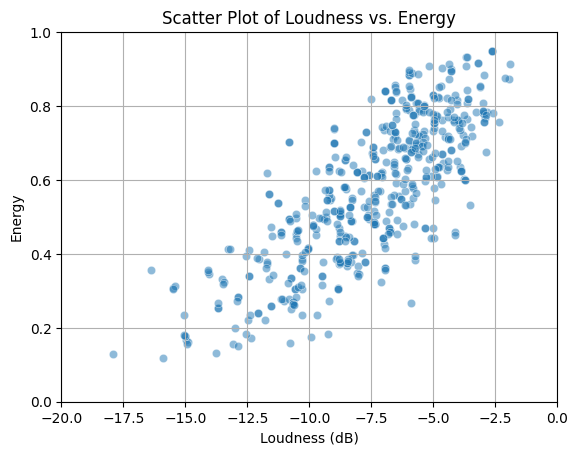

```python
# Calculate Pearson's correlation coefficient (r)
r = df['loudness'].corr(df['energy'])

# Create scatter plot
sns.scatterplot(x = 'loudness', y = 'energy', data = df, alpha = 0.5)
plt.xlim(-20, 0)  # Set x-axis bounds
plt.ylim(0, 1)  # Set y-axis bounds

# Set graph and axes titles
plt.title('Scatter Plot of Loudness vs. Energy')
plt.xlabel('Loudness (dB)')
plt.ylabel('Energy')
plt.grid(True)

# Display correlation coefficient
print(f'r = {r}\n')
```

**Explanation:** Based on the Pearson's correlation coefficient value r = 0.7882937378160497, there is a strong, positive, linear relationship between the loudness and energy of Taylor Swift's songs. Loudness represents the overall loudness of a track, typically ranging from -60 and 0 dB. Loudness is the quality of a sound that is the primary psychological correlate of physical strength (amplitude). Loudness values are averaged across the entire track and are useful for comparing the relative loudness of tracks. Energy is a measure from 0.0 to 1.0 and represents a perceptual measure of intensity and activity. Typically, energetic tracks feel fast, loud, and noisy. For example, death metal has high energy, while a Bach prelude has low energy. Perceptual features contributing to energy include dynamic range, perceived loudness, timbre, onset rate, and general entropy. The conclusion made from Pearson's correlation coefficient value is that the louder Taylor Swift's songs are, the more energy the songs contain. This makes sense because many of Taylor Swift's music are pop and country songs that includes different background tracks and instruments, which makes the music faster, louder, and more energetic.

**Method 2:** Using the Augmented Dickey-Fuller (ADF) hypothesis test to analyze Taylor Swift's song popularity over time

```
P-value: 0.11533516836911045
```

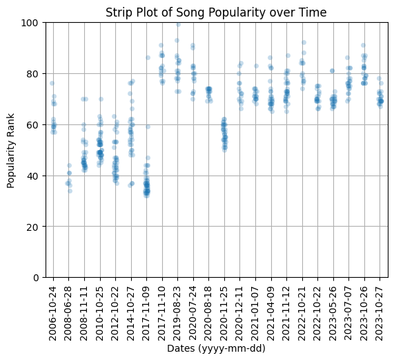

```python
# Create dataframe containing unique release date and mean popularity score of all songs released on that date
popularity_means = df.groupby(df['release_date'])['popularity'].mean().reset_index()

# Create dataframe containing number of songs released on each unique date (reference dataframe)
song_count = df.groupby(df['release_date'])['name'].count().reset_index()

# Assign column names to number of songs dataframe
song_count.columns = ['release_date', 'song count']

# Merge mean popularity dataframe and song count dataframe on release date
df_grouped_dates = pd.merge(popularity_means, song_count, how = 'inner', on = 'release_date')

# Rename merged dataframe columns and sort dataframe by release date (dates in ascending order)
# Crucial for ADF Test to produce accurate results
df_grouped_dates.columns = ['release_date', 'average_popularity_score', 'song count']
df_grouped_dates.sort_values(by = 'release_date', inplace = True)

# Run ADF Test and store results
result = adfuller(df_grouped_dates['average_popularity_score'])

# Assign test-statistic and p_value variables
test_statistic = result[0]
p_value = result[1]
print(f"P-value: {p_value}\n")

# Sort original dataframe by release date for plotting purposes
df.sort_values(by = 'release_date', inplace = True)

# Create strip plot of release date and popularity where each song is a point
sns.stripplot(x = 'release_date', y = 'popularity', data = df, alpha = 0.25)
plt.xticks(rotation=90) # Rotate x-axis date labels
plt.ylim(0, 100)  # Set y-axis bounds

# Set graph and axes titles
plt.title('Strip Plot of Song Popularity over Time')
plt.xlabel('Dates (yyyy-mm-dd)')
plt.ylabel('Popularity Rank')
plt.grid(True)
```

**Explanation:** The Augmented Dickey-Fuller (ADF) hypothesis test is a statistical hypothesis test used to analyze changes in a statistic over time. More specifically, it is used to see whether a time series data column (statistics corresponding to specific times across a certain range) is non-stationary, meaning that over time the mean and variance of the statistic change. It finds the probability of a feature in the series, called a unit root, being present. The null hypothesis is that there is no unit root and the series is stationary, meaning that the mean and variance of the series does not change over time. In other words, we cannot show there is a statistical relation between time and the statistic in the series. Then, the alternative hypothesis is that there is a unit root and the series is non-stationary, so the mean and variance of the series does change over time and there is likely a statistical relation betwenen time and the statistic in the series. The ADF test is helpful because times do not need to be evenly spaced for the test to be effective, so it helps analyze popularity over time, given that Taylor does not release albums exactly evenly spaced apart from each other.

In this test, we used popularity score, determined by Spotify on a scale from 0-100 with 100 being the most popular, as the statistic we want to analyze over time. To deal with songs released on the same dates, we grouped together songs of the same release date and found the average of their popularity score. This works because the scatterplot clearly displays that there is not an excessive difference between any of the popularity scores of songs released on the same date. We also counted the number of songs released on each day to make sure the counts were large enough for this test to be meaningful, which they were. After sorting the resulting dataframe in ascending order by dates, the ADF test was run and produced a p-value of 0.11533516836911045, which is above our level of significance of 0.05 for the test. This means that we keep the null hypothesis suggesting that we cannot conclude there is a significant change in the distribution of popularity score over time. We also cannot say that the release dates and popularity scores are related. Even though the graph would suggest that popularity was slightly increased for later release dates, the difference is not large enough to confidently conclude that release date actually has a correlation with popularity. This would also explain why the p value is pretty small but not quite small enough to reject the null hypothesis since the trend does not appear clear enough to be fully confident that such a relationship would exist.

**Method 3:** Using t-tests to compare the average acousticness of different Taylor Swift albums

```
Reputation vs. Folklore T-statistic: -7.747515073753075
Reputation vs. Folklore P-value: 1.523942528618826e-08
Taylor Swift vs. Midnights T-statistic: -2.0099085354318977
Taylor Swift vs. Midnights P-value: 0.05492382568740831
```

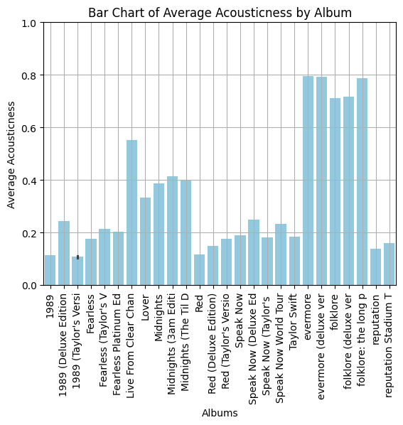

```python
# Group albums by acousticness and graph
grouped_averages = df.groupby('album')['acousticness'].mean().reset_index()
sns.barplot(x = [album[:20] for album in grouped_averages['album']], y = grouped_averages['acousticness'], color = 'skyblue')

# Add labels and title
plt.xlabel('Albums')
plt.ylabel('Average Acousticness')
plt.title('Bar Chart of Average Acousticness by Album')

# Show plot
plt.xticks(rotation = 90) # Rotate x-axis labels for better readability
plt.ylim(0, 1)  # Limit by 1 (Spotify metric)
plt.grid(True)

# T-Test #1: Split data into two albums
reputation = df[df['album'] == 'reputation']['acousticness']
folklore = df[df['album'] == 'folklore']['acousticness']

# Perform two-sample t-test
t_statistic, p_value = ttest_ind(reputation, folklore)

# Print results
print("Reputation vs. Folklore T-statistic:", t_statistic)
print("Reputation vs. Folklore P-value:", p_value)

# T-Test #2: Split data into two albums
tswift = df[df['album'] == 'Taylor Swift']['acousticness']
midnights = df[df['album'] == 'Midnights']['acousticness']

# Perform two-sample t-test
t_statistic, p_value = ttest_ind(tswift, midnights)

# Print results
print("Taylor Swift vs. Midnights T-statistic:", t_statistic)
print("Taylor Swift vs. Midnights P-value:", p_value, "\n")
```

# **Machine Learning Models**

The main takeaway that we got from our preliminary exploration of the Spotify API dataset was that Taylor Swift does not have one fixed style. The third method tells us that Taylor Swift has employed many different sounds with varying levels of acoustic instrumentation, which correspond to the different genres she has employed across her career, such as pop, trap, country, and folk. The first method shows us that her music has consistently had varying levels of energy and bombast throughout her career. Yet from the second method, we can see that her music has remained consistently popular throughout. Based on this information, we are predicting that what has made Taylor Swift's music stick in the public consciousness is her ability to convey emotion of all forms. So one way we can evaluate the performance of Tay-I is by comparing sentiment analysis scores for Tay-I and Taylor's actual lyrics. As for the models themselves, we have decided to try multiple different models and compare their results to see which can best recapture the spriit of Taylor's writing. The first will be a probabilistic model called a Markov chain, which utilizes only the previous words generated to generate the next few words. Markov models, despite not using classic machine learning techniques, are useful because of their ability to match the training data and relatively low time complexity. However, they are not space-efficient and do not actually "learn" the training data. The other model we will use is a Recurrent Neural Network (RNN), which is frequently used for sequential data, such as language. This model does actually fully learn the training data, but it is hard for simpler RNNs to grasp language features and semantics accurately.

## Markov Model Technique

### Markov Model

```python
class MarkovSongGenerator:
  # Initlalize the model by initializing the local variables.
  def __init__(self, lyrics, order = 2, temperature = 1.0):
    self.order = order
    self.start_tokens = []
    self.transitions = {}
    self.lyrics = set(lyrics) # Store set of unique lyrics
    self.temperature = temperature
    self.preprocess(lyrics)

  # Preprocess all lyrics
  def preprocess(self, lyrics):
    for line in lyrics:
      # Split each line of lyrics into words
      words = line.split()

      # Add start tokens ('order' number of words per line)
      self.start_tokens.append(tuple(words[:self.order]))

      # Create transitions from previous group of words to next
      for i in range(len(words) - self.order):
        prefix = tuple(words[i:i + self.order])
        suffix = words[i + self.order]

        if prefix in self.transitions:
          self.transitions[prefix].append(suffix)
        else:
          self.transitions[prefix] = [suffix]

  def sample_word(self, prefix):
    # Laplatian smoothing- prevent any word from having 0 probability to help
    # ensure every word has a small chance of getting picked, which improves
    # randomness.
    transition_probs = self.transitions.get(prefix, [])
    vocab_size = len(set(transition_probs))
    smoothed_probs = {}
    for word in transition_probs:
      smoothed_probs[word] = (transition_probs.count(word) + 1) / (len(transition_probs) + vocab_size)

    # Temperature-based sampling
    # In temperature-based sampling, we divide the logarithm of each probability
    # by the temperature to adjust their relative scaling before calculating
    # their softmax distribution
    probs = np.array(list(smoothed_probs.values()))
    scaled_probs = np.log(probs) / self.temperature
    exp_probs = np.exp(scaled_probs)
    softmax_probs = exp_probs / np.sum(exp_probs)

    # Sample from softmax distribution
    sampled_word = np.random.choice(list(smoothed_probs.keys()), p = softmax_probs)
    return sampled_word

  def training_data_similarity_score(self, gen_line):
    # Check if verse is similar to any training data lines
    for line in self.lyrics:
      if self.similarity_score(line, gen_line) > 0.4:  # Adjust threshold as needed
        return True

    return False

  def similarity_score(self, line1, line2):
    # Calculate similarity score between two verses (simple approach where
    # we compare common words of two lines over their total number of words
    words1 = set(line1.split())
    words2 = set(line2.split())
    intersection = len(words1.intersection(words2))
    union = len(words1.union(words2))

    if union != 0:
      similarity = intersection / union
    else:
      similarity = 0

    return similarity

  def generate_lyrics(self, length = 20):
    # Select random start token (probabilistic)
    curr_prefix = random.choice(self.start_tokens)
    gen_line = list(curr_prefix)
    generated_line = ""

    # Generate verse
    while len(gen_line) < length:
      if curr_prefix in self.transitions:
        # Generate next words, build the verse, and push the previous word index down
        next_word = self.sample_word(curr_prefix)
        gen_line.append(next_word)
        curr_prefix = tuple(gen_line[-self.order:])
      else:
        break

    generated_line = ' '.join(gen_line)

    # Post-generation: Filter out exact and too-close matches with training data
    if generated_line in self.lyrics or self.training_data_similarity_score(generated_line):
      return self.generate_lyrics(length)  # Retry generation

    return generated_line
```

The Markov model is a probabilistic model that utilizes features of the training data to make predictions for what the next word in a generated line should be based on the previous couple of words. In this case, we look at the previous 2 words, because order is 2. We obtain start tokens by looking at the first 2 words of every line, and then progressively add the following 2 words in a line until we reach the end into our transitions dictionary. We then randomly generate a starting word and then sample the word we will add from the list of transitions. To sample, we apply Laplacian smoothing to prevent any word from having 0 probability of being picked, and then utilize temperature-based sampling and exponential normalization (also known as softmax) to generate the final probabilities of words being picked. We then randomly choose a word using these probabilities, and append it to our generated word. At some point, we will reach the end of prefixes in the line, and our generation will be done. As you may suspect, this process is very vulnerable to blatantly copying lines from the training data. To assuage this, we regenerate lines if they are direct copies of the training data, and we also reject any lines that share over 40% of their words with a line from the training data. In this way, our generated lines are based on the training data while maintaining some semblance of uniqueness.

### Markov Model Verse Generator

```python
# Separate lyrics line-by-line from dataframe
lyrics = lyrics_df.iloc[:, 3].tolist()

# Create MarkovSongGenerator class with lyrics as text
generator = MarkovSongGenerator(lyrics)
generated_song = ''

for _ in range(5):  # Number of verses to generate
  for _ in range(10):  # Number of lines to generate
    generated_song += generator.generate_lyrics() + '\n'   # Display the generated verse
  generated_song += '\n'  # Print new line between each verse
print(generated_song)
```

```
Bye bye to everything I thought of you too much to be alone
'Cause you still feel like I got home 'fore I said all that?
Saw you there, to see you everywhere, the only hoax I believe in whatever you do or don't do
Drew looks at me and you walk me to fit in my head on your own shots
I'd give you a second chance
So I tuck you in, and baby, that's when I'll be cleaning up bottles with you for a reason
I think I was too young to be mad love makes you laugh when you wake up by your side
I wish you would, I wish you would come around and make it now (See it now)
For staying back and up the phone and you walk me to find somewhere
And I could stand up and hit the brakes too soon?

Lay the table with the sound of my things at your party
We're on the other side of the dog days)
Got a long night (Oh)
Give me a reason"
He's got a bad drug
He's the reason why
I got lost in a café, I watched all of my life by not being mine
Fell in love anymore
It was the moment stop
And I'd be a phantom

Taking mine, but it's not that easy
All you want to feel your touch
What must it be enough if I get you where the storyline ends
I bet you’re sittin' in your truck, and all I have to lose your girl
God smiles on my face in my party dress
'Cause all I think he did it this time of my head and locking the gates
And spinning out of style, we never go away by making you my wild, give you faith
She underestimated just who I was enchanted to meet you when you wake up in my poems like a little
'Cause when I'd fight, you used to be at a party when I fell from the dead, oh-oh, oh
It's cool, that's what they all look like a battle hero's welcome

I thought we'd have a friend in me and you'll never have to break what I tell 'em
'Cause nobody's gonna love you because you have to go with grace
Addressed to the east, clowns to the hallway, well on my side even when it's cold
We hadn't seen each other like that anyone would die to feel okay again
I still remember the swing over the creek beds we turned up
She can't see it through
But he leaves you out on your window
If a man (Hey)
No one could touch the way your hair and watch you leave me with it
Is this in my head as I drive away with you I love SoCal

And open up and hit the tunnel
You know it used to think that I could feel that much
I used to see you turn right back around here thinking it through
Just take me home but you don't want you for making me feel like you know everything about you long
And I'll never get to hold us back will fall down (Down), down (Down)
Is now it's getting so much about things you can't talk to the garden?
Is it cool that I won't get far (Don't pretend)
2AM, here we are the hands of fate when it all seem new and exciting?
But I will be by your side
Put my name and money
```

For the generator, we first extract just the lyrics from the lyrics dataframe. We create an instance of the Markov song generator, and then we generate lines. Each line is separated by a \n, and each verse is separated by another \n. In total, we have 5 verses of 10 lines each being generated, and stored in the result string.

## Recurrent Neural Network (RNN) Technique

### RNN

```python
# Class not needed since model is relatively simple
# Create a tokenizer for the lyricss
tokenizer = Tokenizer()
tokenizer.fit_on_texts(lyrics)
total_words = len(tokenizer.word_index) + 1

# Create input sequences for the model by tokenizing the lyrics and putting
# the results in a list
input_sequences = []
for line in lyrics:
    token_list = tokenizer.texts_to_sequences([line])[0]
    for i in range(1, len(token_list)):
        n_gram_sequence = token_list[:i+1]
        input_sequences.append(n_gram_sequence)

# Pad the input sequences so they maintain similar size in the model
max_sequence_len = max([len(x) for x in input_sequences])
input_sequences = np.array(pad_sequences(input_sequences, maxlen=max_sequence_len, padding='pre'))

# Create predictors and label
predictors, label = input_sequences[:,:-1],input_sequences[:,-1]

# Convert label to one-hot encoding
label = tf.keras.utils.to_categorical(label, num_classes=total_words)

# Define the RNN model- Sequential for RNN
# Embedding = Split indices into 100 vectors
# Bidirectional LSTM- where the learning actually happens
# Dense- Fully connected layer that uses softmax to produce probabilities
model = tf.keras.Sequential([
    tf.keras.layers.Embedding(total_words, 100, input_length=max_sequence_len-1),
    tf.keras.layers.Bidirectional(tf.keras.layers.LSTM(150)),
    tf.keras.layers.Dense(total_words, activation='softmax')
])
model.compile(loss='categorical_crossentropy', optimizer='adam', metrics=['accuracy'])

# Train the model
model.fit(predictors, label, epochs=50, verbose=1)
```

```
<keras.src.callbacks.History at 0x7e4bdc738fd0>
```

This is an RNN model. First, we create a tokenizer for Taylor's lyrics so that the model can work with them. Then, we create inputs for the model by iterating through Taylor's lyrics and applying the tokenization, appending each result to our list of input sequences. Then, we pad each input sequence at their start to ensure that every sequence passed into the model is exactly the same length. This is crucial to avoid matrix multiplication issues. Now, we create a set of predictors and labels from the input sequences by setting aside the last element of each sequence as a label. After this, we one-hot-encode the labels so the model can work with them more easily.

After this, we can finally create the model itself. We create a sequential model (which is what an RNN is). Next, we embed sequence indices into fixed-length vectors of length 100. After this, we create a Bidirectional LTSM (Long Short-Term Memory) layer, meaning that the layer process input in both forwards and backwards directions. An LTSM works well here because it protects against vanishing gradients and can store a lot of prior information inputted to it. Then, we create a fully connected layer which uses softmax to produce our probabilties. The loss we use is categorial cross-entropy, which is used for a lot of predictive tasks. We fit this model on the input sequences over 50 epochs so it learns the training data.

### RNN Verse Generator

```python
# Sampling with temperature
def sample_word(predicted, temperature = 0.7):
  predicted = np.log(predicted) / temperature
  exp_predicted = np.exp(predicted - np.max(predicted))  # Convert to probabilities
  probs = exp_predicted / np.sum(exp_predicted)  # Normalize probabilities
  sampled_index = np.random.choice(len(probs), p = probs)  # Pick a word
  return sampled_index

# Function to generate lyrics utilizing temperature scaling
def generate_lyrics(max_sequence_length, temperature = 0.7):
  generated_lyrics = ""

  for verse in range(5):  # Number of verses to generate
    for line in range(10):  # Number of lines to generate
      seed_text = random.choice(lyrics)
      prev_word = None
      line_text = ""

      for _ in range(10):  # Generate 10 additional words per line
        # Tokenize our starting word and pad it
        token_list = tokenizer.texts_to_sequences([seed_text])[0]
        token_list = pad_sequences([token_list], maxlen = max_sequence_length - 1, padding = 'post')
        predicted = model.predict(token_list)[0]  # Get the prediction for the next word

        # Sample from the predicted distribution with temperature scaling
        predicted_index = sample_word(predicted, temperature = temperature)

        while predicted_index == tokenizer.word_index.get(prev_word):
          # Choose another word if it's the same as the previous word
          predicted[predicted_index] = 0  # Set the probability of the previous word to 0 so it does not appear in the next sample
          predicted_index = sample_word(predicted, temperature = temperature)

        output_word = tokenizer.index_word[predicted_index] # Extract the word
        prev_word = output_word
        seed_text += " " + output_word # Add spaces between word so token has more information
        line_text += " " + output_word # Add spaces between words in output

      generated_lyrics += line_text.strip() + "\n"  # Add line to verse
    generated_lyrics += "\n"  # Add newline after each verse
  return generated_lyrics

# Generate lyrics!
# Experimented with different temperatures between 0.4 and 2, settled on 0.7
generated_lyrics = generate_lyrics(max_sequence_len, temperature = 0.7)
print(generated_lyrics)
```

```
you're this ain't you i've this can december this everything
you this miss holding you died haven't riddles knew why
queens film said smiles something you do i've been gone
you i've still started i've this what road you're you
you waitress you this you know where you've been enough
i've how i've i'm look this you'll we already you're
how boys train are without do you without no up
will i've lights golden never would ooh film meet how
already you tied national waitress you'll you're stay you stay
waitress nothing do can't look anything back to sleep to

you'll december riddles never you'll just that that's i should
i've do i've you this you it's oh you're alone
i've never it's you i've hey you you're i you're
you'll meet heir song heir you our town burned now
look you this didn't you it at me world nobody
saw this you this wanna look you back at my
princess fall aisle fall list pageant casually imagined hero list
i've you steel do nothing you how do you heard
west archer you never what you let do oh crowd
you'll never this smiles i've you'll my age king mornin'

watch you wrapped ooh we i've do steel do this
would will you believed it's believed does am fight could
you look this you you'll how this we caught never
you'll you weight you'll would do you run and baby
woods list woods list fall list schemes casually cycle lakes where
i've do i've waitress break you steel road steel list
that would never nice honey forever and games you no
smiles i've you'll i've you you'll do you all you
you noise heat you hey you're gone you oh you
would once get knows you do you what you what

i've do woods do you'll do can't way fences it
you'll would you'll the bone list saw we someone canceled
you'll i've my never look this you're you'll list weaker
like ruin this you're this like you're look this afterglow
i've do never you'll i've miss never you'll you e
look lights now you romeo run i run i fly
december ain't would this look this road december road world
grass once you this i've you're trying for forgiveness at
i've do smiles never lakes road mornin' weaker blood phone
you'll never i've you i've strike you'll west princess upon

king list you now i'm our girl in girl list
wanna do you waitress do got this do you way
you you're you that the can't light things one of
morning do you morning saw ooh it's i'm of shine
you'll smiles film babe this i'm love that our school
do you're ooh are wanna oh back to you at
found bring said haunt said thе you babe you used
waitress this you'll world son run draw heir memories i'll
this i've you i've you once you would you what
you this you this i’ll king you i'm you e
```

This is how we generate verses using the RNN. We first generate a starting series randomly from Taylor’s lyrics and then tokenize it. From there, we pad it and then pass it into the model, which returns its predictions for probability distributions. Then, we sample a word from these probabilities using temperature scaling, where we divide by temperature and then normalize using exponentials to create our new rescaled probabilities, from which we then pick a word. If the word is the same as the previous word, we regenerate to prevent stagnation by setting its probability equal to 0 for that specific word generation so it will not show up. We extract the word back out of the tokenizer and concatenate it to a string. We repeat this process 10 times to create a line, we create 10 lines to make a verse, and then we create 5 verses.

# **Primary Analysis**

The first metric we will use for analysis is Bilingual Evaluation Understudy, or BLEU score. BLEU was originally used for detemrining the quality of machine translation, but for NLP it allows us to compare the similarity of model-generated text to original human-generated text. As such, we will compare the samples from the Markov model and the RRN model to Taylor's original lyrics using BLEU score. BLEU works by weighted valuation of similar n-grams, which are sequences of specific words of length n. We can split both Taylor's lyrics and our generated lyrics into lists of words and then calculated BLEU using the Natural Language Toolkit.

## Bilingual Evaluation Understudy (BLEU) Score for Markov Model

```python
weights = (0.4, 0.3, 0.2, 0.1)  # Weights for uni-gram, bi-gram, tri-gram, and 4-gram
# We are weighting each n-gram progressively less, because as n increases the probability
# of an n-gram match becomes less and less

# Split baseline lyrics (Taylor swift dataset) and generated lyrics
lyrics_words = [sentence.split() for sentence in lyrics]
lines = generated_song.split('\n')
generated_words = [word for line in lines for word in line.split()]

# Calculate BLEU score utilizing our weights and a smoothing function
score = sentence_bleu(lyrics_words, generated_words, weights = weights)
print(score)
```

```
0.6831405397525627
```

## Bilingual Evaluation Understudy (BLEU) Score for RNN

```python
weights = (0.65, 0.32, 0.03, 0)  # Weights for uni-gram, bi-gram, tri-gram, and 4-gram
# We are weighting each n-gram progressively less, because as n increases the probability
# of an n-gram match becomes less and less

# Split baseline lyrics (Taylor swift dataset) and generated lyrics
lyrics_words = [sentence.split() for sentence in lyrics]
lines = generated_lyrics.split('\n')
generated_words = [word for line in lines for word in line.split()]

# Calculate BLEU score utilizing our weights and a smoothing function
score = sentence_bleu(lyrics_words, generated_words, weights = weights)
print(score)
```

```
0.2646917307369639
```

BLEU scores are always between 0 and 1, with a score closer to 1 meaning the generated text corresponds more closely to the original training data, and a score closer to 0 meaning the generated text does not correspond very closely to the original. The Markov model has a score of 0.68, which means that it is fairly close to the original training data and is performing well. The RNN model has a less good score of 0.26, but considering that it is a more general-purpose model compared to the training data it makes sense that it would not fit as closely to the training data.

## Sentiment Analysis

Here, we also analyze the sentiments of our lyrics dataset with the lyrics generated by our models. The sentiments were generated by using the Vader sentiment analyzer provided by NLTK. Vader is a rules-based analyzer commonly used for social media and business sentiment analysis. We chose it because it was the simplest to use by far while still providing fairly accurate results. In this case, we use Vader to generate polarity scores, which roughly represent the valence or intentisty of the text it is analyzing. It is somewhat analogous to the valence score given to Taylor Swift's songs by Spotify, although this is purely based on lyrics. From those scores, we attach a label to the lyric based on whether the score is above, below, or equal to zero. The results of random samples of Taylor's lyrics is compared to randomly generated verses of the Markov Model and RNN are shown in the grouped bar chart above. We found that while our Markov model refelcts negativity in Taylor's lyrics well, it overly favors positive sentiment while Taylor tends to be more neutral.

```python
class SentimentAnalyzer():
  def __init__(self, lyrics, title):
    # NLTK initialization
    self.lemmatizer = WordNetLemmatizer()
    self.analyzer = SentimentIntensityAnalyzer()

    # preprocessing and analysis
    self.tokens = self.preprocess_lyrics(lyrics)
    self.sent_counts = {}
    self.sentiments = self.get_sentiments(self.tokens)

    self.title = title

  def preprocess_lyrics(self, lyrics):
    processed_lyrics = []
    for lyric in lyrics:
      # tokenization
      tokens = word_tokenize(lyric.lower())
      # removing stop words ("the", "is", "a", etc.)
      filtered_tokens = [token for token in tokens if token not in stopwords.words('english')]
      # lemmatization (grouping together word variations like "stop" and "stopping")
      lemmatized_tokens = [self.lemmatizer.lemmatize(token) for token in filtered_tokens]
      processed_lyrics.append(' '.join(lemmatized_tokens))
    return processed_lyrics

  def get_sentiments(self, lyrics):
    sentiments = []
    for lyric in lyrics:
      # get the valence of a line from intensity analyzer
      score = self.analyzer.polarity_scores(lyric)
      # group scores into positive, negative, and neutral sentiment
      if score['compound'] > 0:
        sentiment = "positive"
      elif score['compound'] < 0:
        sentiment = "negative"
      else:
        sentiment = "neutral"
      sentiments.append(sentiment)

    # count number of positives, negatives, neutrals in data
    self.sent_counts["pos"] = reduce(lambda acc, x: acc + 1 if x == "positive" else acc, sentiments, 0)
    self.sent_counts["neg"] = reduce(lambda acc, x: acc + 1 if x == "negative" else acc, sentiments, 0)
    self.sent_counts["neut"] = reduce(lambda acc, x: acc + 1 if x == "neutral" else acc, sentiments, 0)

    return sentiments

  # singular bar chart visualization for
  def visualize(self):
    plt.bar(["Positive", "Neutral", "Negative"], [self.sent_counts["pos"], self.sent_counts["neut"], self.sent_counts["neg"]], color=['green', 'red', 'blue'])
    plt.xlabel('Sentiments')
    plt.ylabel('Count')
    plt.title(f'Sentiment Analysis of {self.title}')
    plt.show()

  @staticmethod
  # compares counts of sentiment for two sets of lyrics
  def group_visualize(analyzer1, analyzer2, analyzer3):
    # Create subplots
    fig, axes = plt.subplots(1, 3, figsize=(15, 5))

    # Data for each analyzer
    analyzers = [(analyzer1, axes[0]), (analyzer2, axes[1]), (analyzer3, axes[2])]

    for analyzer, ax in analyzers:
        counts = [analyzer.sent_counts["pos"], analyzer.sent_counts["neut"], analyzer.sent_counts["neg"]]
        X = ["Positive", "Neutral", "Negative"]
        X_axis = np.arange(3)

        # Plot bar graph
        ax.bar(X_axis, counts, label=analyzer.title)
        ax.set_xticks(X_axis)
        ax.set_xticklabels(X)
        ax.set_xlabel("Groups")
        ax.set_ylabel("Number of Words")
        ax.set_title(f"Number of Words in each Sentiment Group ({analyzer.title})")
        ax.legend()

    plt.tight_layout()
    plt.show()
```

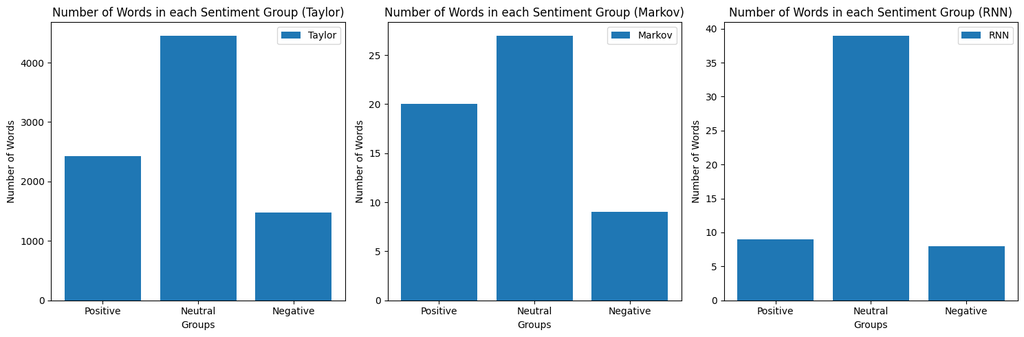

```python
# use constructor SentimentAnalyzer([], "") to analyze lyrics
tay_sentiment = SentimentAnalyzer(lyrics, "Taylor")
markov_sentiment = SentimentAnalyzer(generated_song.split("\n"), "Markov")
rnn_sentiment = SentimentAnalyzer(generated_lyrics.split("\n"), "RNN")
# use static method SentimentAnalyzer.group_visualize(analyzer1, analyzer2) to compare two sets of results
SentimentAnalyzer.group_visualize(tay_sentiment, markov_sentiment, rnn_sentiment)
```

Sentinment analysis is the the process of analyzing text to determine whether its emotional tone is positive, negative, or neutral. We ran sentiment analysis on the original text, the generated text from the Markov Model, and the generated text from the RNN. From the bar graphs, we can see that the original lyrics and the Markov Model generated lyrics split the words into the three categories relatively similarly. However, the RNN model classifies most of the words as neutral. This suggests that the RNN model is not that good at capturing sentiment.

# **Visualizations**

## Word Cloud

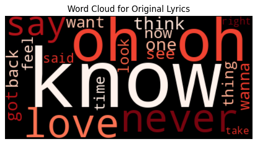

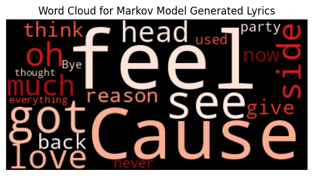

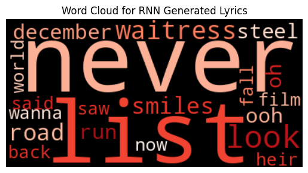

```python
# Filter out stop words
stop_words = set(stopwords.words('english'))

# Create and display word cloud for original lyrics
all_lyrics = ''.join(lyrics_df.iloc[:, 3].tolist())

wordcloud = WordCloud(background_color = 'black', colormap = 'Reds', max_words = 20).generate(all_lyrics)
plt.imshow(wordcloud, interpolation = 'bilinear')
plt.title('Word Cloud for Original Lyrics')
plt.axis('off')
plt.show()

# Create and display word cloud for Markov Model generated song
wordcloud = WordCloud(background_color = 'black', colormap = 'Reds', max_words = 20).generate(generated_song)
plt.imshow(wordcloud, interpolation = 'bilinear')
plt.title('Word Cloud for Markov Model Generated Lyrics')
plt.axis('off')
plt.show()

# Create and display word cloud for RNN generated song
wordcloud = WordCloud(background_color = 'black', colormap = 'Reds', max_words = 20).generate(generated_lyrics)
plt.imshow(wordcloud, interpolation = 'bilinear')
plt.title('Word Cloud for RNN Generated Lyrics')
plt.axis('off')
plt.show()
```

The first set of visualizations are several wordclouds consisting of the top 20 words from each text source. In total, 3 wordclouds are created: one for the original lyrics, one for the Markov Model generated lyrics, and one for the RNN generated lyrics. From looking at these wordclouds, the Markov Model wordcloud contains many words seen in the original lyric wordcloud. This suggests that many of the top said words in Taylor Swift's songs are being generated by the Markov Model. Both the Markov Model and the RNN does not generate new words and only uses words found in Taylor's lyrics. This means that the Markov model can predict top frequent words and their transitions better than the RNN model. The RNN model mostly produces unintelligible output, where each line of words means nonsense. Also, the color of the wordclouds represent the theme of Taylor Swift.

## Bar Graph of Frequent Words

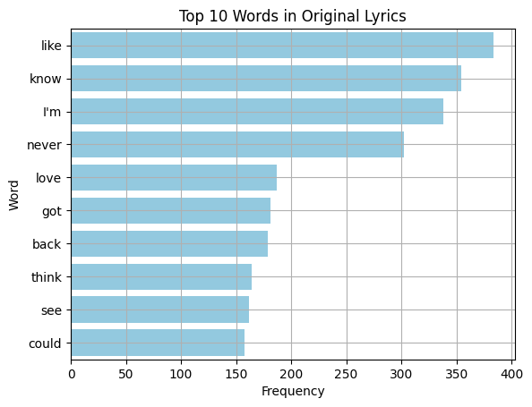

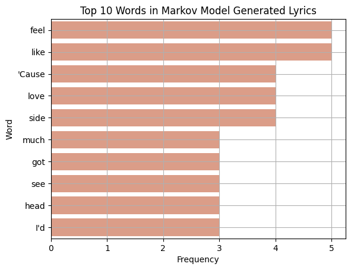

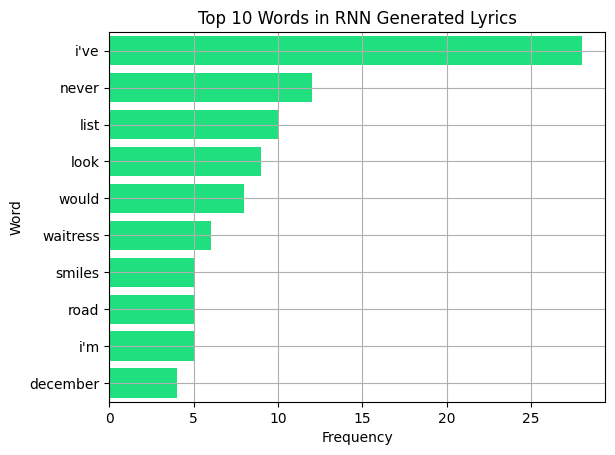

```python
# Count word frequency
def word_freq(text):
  word_freq = {}
  words = text.split()

  for word in words:
    # Filter out stopwords
    if word.lower() not in stop_words:
      word_freq[word] = word_freq.get(word, 0) + 1
  return word_freq

# Sort and retrive top n words
def top_words(word_freq, n):
  sorted_word_freq = sorted(word_freq.items(), key = lambda x: x[1], reverse = True)
  return dict(sorted_word_freq[:n])

# Get top 10 most frequent words
top_original_lyrics = top_words(word_freq(all_lyrics), 10)
top_generated_lyrics = top_words(word_freq(generated_song), 10)
top_RNN_generated_lyrics = top_words(word_freq(generated_lyrics), 10)

# Create dataframes for original lyrics and generated lyrics
df_original_lyrics = pd.DataFrame({'Word': list(top_original_lyrics.keys()), 'Frequency': list(top_original_lyrics.values())})
df_generated_lyrics = pd.DataFrame({'Word': list(top_generated_lyrics.keys()), 'Frequency': list(top_generated_lyrics.values())})
df_RNN_generated_lyrics = pd.DataFrame({'Word': list(top_RNN_generated_lyrics.keys()), 'Frequency': list(top_RNN_generated_lyrics.values())})

# Plot bar graph for original lyrics
sns.barplot(x = 'Frequency', y = 'Word', data = df_original_lyrics, color = 'skyblue')
plt.title('Top 10 Words in Original Lyrics')
plt.xlabel('Frequency')
plt.ylabel('Word')
plt.grid()
plt.show()

# Plot bar graph for Markov Model generated lyrics
sns.barplot(x = 'Frequency', y = 'Word', data = df_generated_lyrics, color = 'darksalmon')
plt.title('Top 10 Words in Markov Model Generated Lyrics')
plt.xlabel('Frequency')
plt.ylabel('Word')
plt.grid()
plt.show()

# Plot bar graph for RNN generated lyrics
sns.barplot(x = 'Frequency', y = 'Word', data = df_RNN_generated_lyrics, color = 'springgreen')
plt.title('Top 10 Words in RNN Generated Lyrics')
plt.xlabel('Frequency')
plt.ylabel('Word')
plt.grid()
plt.show()
```

The second set of visualizations are histograms consisting of the top 10 words from the original lyrics, Markov Model generated lyrics, and the RNN generated lyrics. This is a further inspection of the top 20 words found in each of the model's respective wordcloud. The top 10 frequent words on this graph don't include stop words. However, some of the top words on the graph may seem like stopwords, such as like or I'm. Similar to the wordclouds, the Markov Model generated text contains many similar words seen in the original lyric.

# **Insights and Conclusions**

Our initial goal with this project was to recreate songs in the style of Taylor Swift using machine learning models for text generation. We wanted to explore different types of models to perform this task, so we made a Markov chain model and a recurrent neural network (RNN). To evaluate how well our models performed, we calculated BLEU score and performed sentiment analysis to see how well the emotion of Taylor's original lyrics transferred over to the generated lyrics. We also made some wordclouds and bar graphs to display the frequency of words in both original lyrics and generated to see if the main ideas were coming across.

Overall, we can draw some interesting conclusions from this experiment. The Markov model seemed to show conclusively that it is possible to recreate the general style of Taylor’s lyrics probabilistically. The model was not perfect and often did not directly recreate language semantics, but the BLEU score of 0.68 and relatively coherent sentence structure shows us that it could recreate Taylor’s vibe pretty convincingly. Furthermore, it had a similar ratio of sentiments (positive, neutral, and negative) to Taylor’s original lyrics. A lot of the top words were very similar to the original lyrics, such as "love" and "think", as they showed up frequently in both the original lyrics and the Markov-generated lyrics. Meanwhile, the RNN model was not as good at doing so, as it tended to miss semantics and pair a lot of words together that created nonsense combinations. The BLEU score of 0.26 was relatively poor as well. Interestingly, it seemed to produce a much higher ratio of neutral words and fewer positive and negative words than the Markov model, which suggests that it was not as good at capturing sentiment, either. The top words were not as close of a match as the Markov model's lyrics provided. However, the one upside it does have over the Markov model is that the Markov model is pretty tied to the training data, so it cannot really be applied effectively to any other data. The RNN model, on the other hand, can absolutely be tested on any other input dataset pretty easily, and will be far more generalizable. In the future, we hope to explore more complex and layered RNNs to see if we can improve the quality of our generation.

# **Additional Resources**

https://www.tensorflow.org/text/tutorials/text_generation - This is a great resource if you want insight on building increasingly more complicated RNNs for text generation.

https://www.datacamp.com/tutorial/text-analytics-beginners-nltk - This is a fantastic tutorial that can be used to perform sentiment analysis using the NLTK library.

https://www.geeksforgeeks.org/markov-chains-in-nlp/# - This is a solid guide for understanding how Markov chains can be useful in the context of NLP.

https://www.analyticsvidhya.com/blog/2020/05/what-is-tokenization-nlp/ - This provides more guidance about how tokenization works in NLP.

https://machinelearningmastery.com/time-series-data-stationary-python/ - An interesting blog post about hypothesis tests for time series analysis. Time series analysis deals with understanding how data changes over time.